# R Notebook - Module 1 Homework 2 - Answers

Corey S. Sparks, PhD - UTSA

# R Homework Example 1

In this example, you will first read in the American Community Survey Public-Use Microdata to examine income distributions among workers with a Ph.D. degree. This example uses a survey data source similar to what you will use in the ADRF.

**If you have not yet watched the “Introduction to Jupyter Notebooks” video, watch it before you proceed!**

**NOTE: When you open a notebook, make sure you run each cell containing code from the beginning. Since the code we’re writing builds on everything written before, if you don’t make sure to run everything from the beginning, some things may not work.**

**Note, if you’re running this on your personal computer, you will need to install packages beforehand, but if you’re on the ADRF, the packages are installed already**

*install.packages(c(“tidyverse”, “car”))*

```r
library(tidyverse)
library(car)
```

### Read in Census American Community Survey Microdata

In this workbook, we will be using 2019 American Community Survey Public Use Microdata (PUMS). These are public-use data sets containing information about responses to the Census Bureau American Community Survey. Information about the ACS project can be found at https://www.census.gov/programs-surveys/acs.

We will be using the ACS PUMS dataset for Texas and California in our examples in this workbook.

You can find more information about the ACS datasets [here](https://www.census.gov/programs-surveys/acs/microdata/access.2019.html) and the Codebook for the data [here](https://raw.githubusercontent.com/coreysparks/data/master/pums_vars.csv).

```r
census <- read_csv(url("https://github.com/coreysparks/r_courses/blob/master/data/pums_tx_ca_2019.csv?raw=true"), show_col_types = F)
```

```r
head(census)
```

```
## # A tibble: 6 x 22
##   SERIALNO   SPORDER  WGTP PWGTP  WAGP  AGEP ST    SCHL    SEX   ESR FOD1P HISP
##   <chr>        <dbl> <dbl> <dbl> <dbl> <dbl> <chr> <chr> <dbl> <dbl> <dbl> <chr>
## 1 2019GQ000~       1     0    67     0    25 48    12        1     6  1099 02
## 2 2019GQ000~       1     0    28  6000    18 06    16        2     6  1099 01
## 3 2019GQ000~       1     0    43  7200    19 48    19        1     1  1099 01
## 4 2019GQ000~       1     0     4  9800    21 06    19        1     1  1099 02
## 5 2019GQ000~       1     0    81     0    54 06    16        2     6  1099 01
## 6 2019GQ000~       1     0    19     0    55 48    16        1     6  1099 02
## # ... with 10 more variables: OCCP <chr>, RAC1P <dbl>, ST_label <chr>,
## #   SCHL_label <chr>, SEX_label <chr>, ESR_label <chr>, FOD1P_label <chr>,
## #   HISP_label <chr>, OCCP_label <chr>, RAC1P_label <chr>
```

## Variables we will use in this example

In this example and homework we will work with a few of the variables in this data.

#### SEX = Respondent’s self idenfied sex

#### SCHL = Respondent’s self idenfied educational attainment

#### ESR = Respondent’s self idenfied employment status

#### HISP = Respondent’s self idenfied Hispanic ethnicity

#### RAC1P = Respondent’s self idenfied race

#### ST = Respondent’s state of residence

Specific codes and response options can be found in the codebook

# Basic visualization using ggplot and dplyr

```r
library(car)
census_sub <- census %>%
    filter(ESR %in% c(1,2),  #select people who are employed
          WAGP !=0 & is.na(WAGP)!=T, #select people with recorded wages
          SCHL == 24)%>% # select only doctoral recipients
    mutate(sex2 = Recode (SEX, recodes = "1='Male'; 2='Female' "),
              as.factor=TRUE) #create new sex variable with labels instead of numbers

census_sub%>%
    select(sex2, WAGP)%>%
    head()
```

```
## # A tibble: 6 x 2
##   sex2     WAGP
##   <chr>   <dbl>
## 1 Male    90000
## 2 Male    25000
## 3 Male    90000
## 4 Male    68000
## 5 Female 120000
## 6 Male   118000
```

### Homework Assignment Answers

1. Calculate the **average wage** for both states and report it

```r
census_sub%>%
    group_by(ST)%>%
    summarize(mean_inc  = mean(WAGP, na.rm=T),
             n_obs = n())
```

```
## # A tibble: 2 x 3
##   ST    mean_inc n_obs
##   <chr>    <dbl> <int>
## 1 06     143006.  3529
## 2 48     119847.  1608
```

2. Make a bar chart of the **average wage** in both states

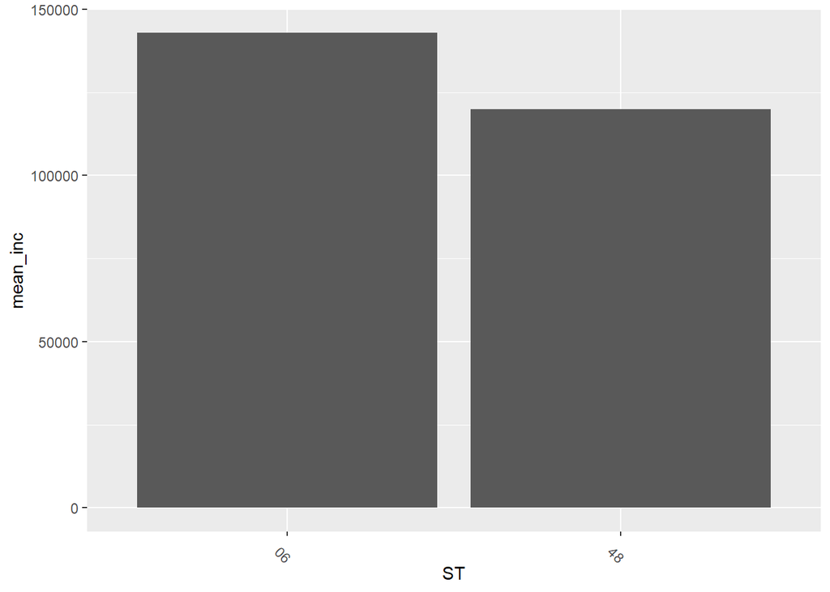

```r
census_sub%>%
    group_by(ST)%>%
    summarize(mean_inc  = mean(WAGP, na.rm=T),
             n_obs = n())%>%
  ggplot(aes(x=ST, y=mean_inc))+
  geom_col()+
    theme(axis.text.x=element_text(angle =-45))
```

3. Make a histogram of the wage distributions in both states

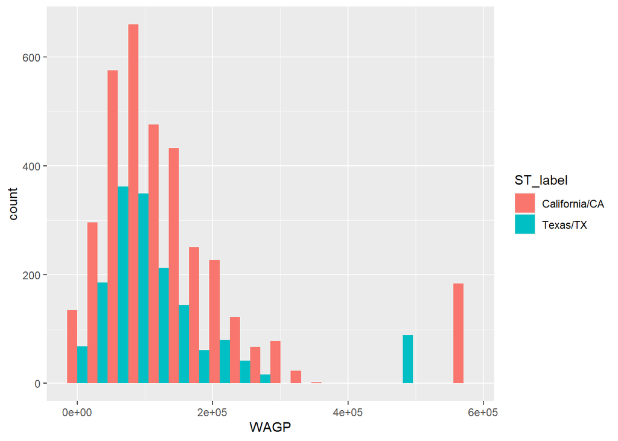

```r
census_sub%>%
    ggplot(mapping = aes(fill=ST_label, group=ST_label, x=WAGP))+
    geom_histogram(position="dodge", bins=20) #position="dodge" plots the lines next to each
```

4. Make a box and whisker plot for wage distributions in both states

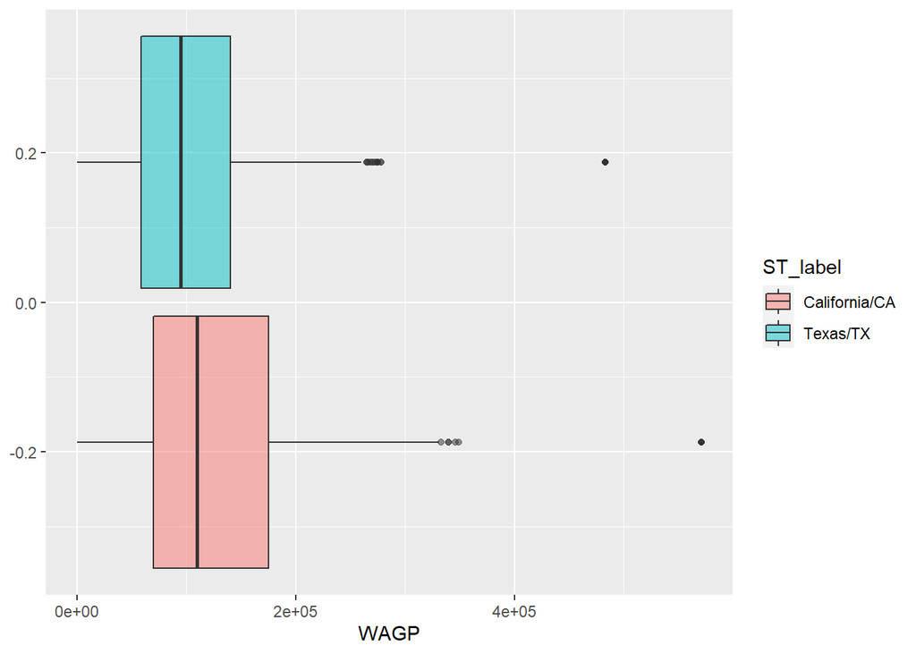

```r
census_sub%>%
    ggplot(mapping = aes(fill=ST_label, group=ST_label, x=WAGP))+
    geom_boxplot(alpha=.5)
```

In general, think about what the differences are between the two states. What do you think this might represent?